# Day 1

- 1. Development Tools:

• Used Jupyter Notebook and VS Code for Python development.

- 2. Variables and Data Types:

• Main data types: int, float, str, and bool.

- 3. Operators:

• Learned arithmetic (+, -, *, /), comparison (==, >, <), and logical (and, or) operators.

- 4. Control Flow:

• Used if, elif, and else for conditional logic.

- 5. Loops:

• Repeated tasks using for and while loops.

- 6. Functions:

• Defined reusable code blocks with def. • Passed arguments and used return to get outputs.

- 7. Numpy Basics:

• Worked with arrays for mathematical operations (e.g., sum, mean).

```python
x=5
type(x)
```

```
int
```

```python
y=3.1
type(y)
```

```
float
```

```python
name="ragd"
type(name)
```

```
str
```

```python
is_active=True
type(is_active)
```

```
bool
```

- if

```python
x=9
if x>5:
    print("x is greater than 5")
```

```
x is greater than 5
```

- if-elif-else

```python
x=9
if x < 5:
    print("x is less than 5")
elif x >10:
    print ("x is greater than 10")
else :
    print("x is less than 10")
```

```
x is less than 10
```

- for loop example

```python
for i in range (6):
    print(i)
```

```
0
1
2
3
4
5
```

- whil loop example

```python
count=1
while count <5:
    print( count)
    count +=1
```

```
1
2
3
4
```

- function syntax

```python
def function(wajed,alanazi):
    print(f"first name,{wajed},last name{alanazi}!")
function("wajed","alanazi")
```

```
first name,wajed,last namealanazi!
```

- Create a program check if a Number is Positive, Negative, or Zero

```python
 num= int (input ("enter num :"))
if num >0:
    print(f"pos")
elif num <0:
    print(f"neg")
```

- Create a simple calculator program that takes user input and performs basic operations like addition, subtraction, multiplication, and division.

```python
num1= float(input ("enter num 1:"))
num2= float(input ("enter num 2:"))
operator= input ("enter operator:")
num3 =0
if operator=="+":
    num3=num1+num2
elif operator =="-":
    num3=num1-num2
elif operator =="*":
    num3=num1*num2
elif operator =="/":
    if num2 !=0:
        num3=num1*num2
    else:
        print("لا تقبل القسمه على الصفر")
        print(num3)
```

- Create a program that prints multiplication tables (e.g., for number 5, print 5x1, 5x2, etc.)

```python
num=int(input("enter a number:"))
for i in range(1,11):
    print(f"{num}*{i}=  "+str(num*i))
```

```
4*1=  4
4*2=  8
4*3=  12
4*4=  16
4*5=  20
4*6=  24
4*7=  28
4*8=  32
4*9=  36
4*10=  40
```

- Create a program that takes an integer input and prints if the number is even or odd.

```python
num= int(input("enter an integer:"))
if num %2==0:
    print("even")
else:
    print("odd")
```

# Day2

- 1. Lists:

• Ordered collection of items (numbers, strings, etc.). • Operations: add, remove, modify, and slice.

- 2. Dictionaries:

• Key-value pairs. • Operations: add, modify, delete, and access values using keys.

- 3. Tuples:

• Ordered and immutable collection. • Operations: access elements and slicing.

- 4. Sets:

• Unordered collection of unique items. • Operations: add, remove, union, and intersection.

- 5. Additional Activities:

• Sum numbers, find the largest and smallest, and count occurrences in lists.

```python
my_list=list(range(1,11))
my_list
```

```
[1, 2, 3, 4, 5, 6, 7, 8, 9, 10]
```

- adding an item

```python
my_list.append(15)
```

- modifying an item

```python
my_list[1]=20
```

```python
print(my_list[2:])
```

```
[3, 4, 5, 6, 7, 8, 9, 10, 15]
```

- creating a dictionary

```python
my_dict={"name":"alice","age":25}
my_dict
```

```
{'name': 'alice', 'age': 25}
```

```python
name=my_dict["name"]
my_dict
```

```
{'name': 'alice', 'age': 25}
```

```python
 my_dict["city"]="new york"
my_dict
```

```
{'name': 'alice', 'age': 25, 'city': 'new york'}
```

```python
my_dict["age"]=30
my_dict
```

```
{'name': 'alice', 'age': 30, 'city': 'new york'}
```

```python
del my_dict["name"]
my_dict
```

```
{'age': 30, 'city': 'new york'}
```

```python
my_dict.keys()
```

```
dict_keys(['age', 'city'])
```

```python
my_dict.items()
```

```
dict_items([('age', 30), ('city', 'new york')])
```

```python
my_dict.values()
```

```
dict_values([30, 'new york'])
```

- Create adictionary with keys name,age,and city.

```python
my_waj={"name":"wajed","age":"22","city":"tabuk"}
my_waj
```

```
{'name': 'wajed', 'age': '22', 'city': 'tabuk'}
```

- Change the value for age to 25

```python
my_waj["age"]=25
my_waj
```

```
{'name': 'wajed', 'age': 25, 'city': 'tabuk'}
```

- Add a key-value pair for email.

```python
my_waj["email"]="waj@ed"
my_waj
```

```
{'name': 'wajed', 'age': 25, 'city': 'tabuk', 'email': 'waj@ed'}
```

- Remove the city key

```python
del my_waj["city"]
my_waj
```

```
{'name': 'wajed', 'age': 25, 'email': 'waj@ed'}
```

```python
my_tapel=(1,2,3,4,5)
my_tapel
```

```
(1, 2, 3, 4, 5)
```

```python
my_tapel[1]
```

```
2
```

```python
my_set={1,2,3,4}
```

```python
my_set
```

```
{1, 2, 3, 4}
```

```python
my_set.update([8,9])
```

```python
my_set
```

```
{1, 2, 3, 4, 8, 9}
```

```python
set1={1,2,3}
set2={3,4,5}
set1|set2
```

```
{1, 2, 3, 4, 5}
```

```python
set1&set2
```

```
{3}
```

```python
set1-set2
```

```
{1, 2}
```

```python
sum(my_set)
```

```
27
```

```python
max(my_set)
```

[output not shown]

```python
min(my_set)
```

```
1
```

```python
number=[7,8,9,10]
sum(number)
```

```
34
```

```python
sum_number=0
```

- Create a simple program to sum of numbers in a list

```python
for i in number:
 sum_number+= i
print("sum of number:",sum_number)
```

[output not shown]

- Create a simple program to find maximum and minimum number

```python
min(number)
```

```
7
```

```python
max(number)
```

```
10
```

- Create a simple program to Count the occurrences of each number in the list

```python
list=[1,2,3,3,3,3,4]
nt=list.count(3)
print(nt)
```

```
4
```

- reate a simple program to print the even numbers in a list.

```python
list=[4,5,6,7]
for i in range(len(list)):
    if list[i]%2==0:
        print(list[i])
```

```
4
6
```

# Day 3

- 1. File Handling:

• Opening Files: Using open() in various modes (r, w, a, rb, wb). • Writing Files: Using write() and writelines(). • Reading Files: Using read() and readlines(). • Closing Files: Prefer using the with statement to automatically close files.

- 2. Python Libraries for AI:

• Pandas: For data cleaning and analysis using structures like DataFrame and Series. • Numpy: For mathematical operations and handling multi-dimensional arrays. • Matplotlib: For creating graphs, plots, and visualizing data.

- writing files

```python
with open('output.text','w')as file:
    file.write("hello,world")
```

```python
lines =["first line/,""third line/n"]
with open ('output.txt','w')as file:
    file.writelines(lines)
```

```python
with open('output.txt','a')as file:
    file.write("appending a new line.")
```

- reading files

```python
with open ('output.txt','r')as file:
    content=file.read()
    print(content)
type(content)
```

```
appending a new line.
```

```
str
```

```python
with open ('output.txt','r') as file:
    lines = file.readlines()
    for line in lines:
        print (line.strip())
        type(lines)
```

```
appending a new line.
```

- 'rb' and 'eb' modes

```python
with open('PHOTO-.jpg','rb') as file:
    binary_data=file.read()
```

```python
with open('PHOTO-.jpg','wb') as new_file:
    new_file.write(binary_data)
```

- Python Libraries for AI

```python
import pandas as pd
data={"name":['john','anna','peter','linda'],
      "age":[28,24,35,40],
      "city":['new york','paris','berlin','london']}
df = pd.DataFrame(data)
print(df)
```

```
    name  age      city
0   john   28  new york
1   anna   24     paris
2  peter   35    berlin
3  linda   40    london
```

```python
Maxage = df["age"].max()
print(Maxage)
```

```
40
```

```python
Minage=df["age"].min()
Minage
```

```
24
```

```python
import pandas as pd
df=pd.DataFrame ({'name':['john','anna','peter',None],
                  'age':[28,None,35,40],})
df.fillna({'name':'unknown','age':df['age'].mean()},inplace=True)
print(df)
```

```
      name        age
0     john  28.000000
1     anna  34.333333
2    peter  35.000000
3  unknown  40.000000
```

```python
import pandas as pd
data={"name": ['john', 'anna', 'peter', 'linda'],
      "Age": [28, 24, 35, 40],
         "Salary": [40000, 50000, 60000, 70000] }
df=pd.DataFrame(data)
filtered_df= df[df["Age"]> 30]
print(filtered_df)
average_salary = df["Salary"].mean()
print(f"Average Salary: {average_salary}")
```

```
    name  Age  Salary
2  peter   35   60000
3  linda   40   70000
Average Salary: 55000.0
```

```python
import numpy as np
arr=np.array([1,2,3,4,5])
arr_sum= np.sum(arr)
arr_mean = np.mean(arr)
print(f"sum:{arr_sum}, Mean:{arr_mean}")
```

```
sum:15, Mean:3.0
```

```python
arr.shape
```

```
(5,)
```

```python
import numpy as np
arr2= np.array([[1,2,3],[4,5,6]])
result=arr2*arr2
print(result)
```

```
[[ 1  4  9]
 [16 25 36]]
```

```python
arr2-arr2
```

```
array([[0, 0, 0],
       [0, 0, 0]])
```

```python
maxx=np.max(arr2)
maxx
```

```
6
```

```python
minn=np.min(arr2)
minn
```

```
1
```

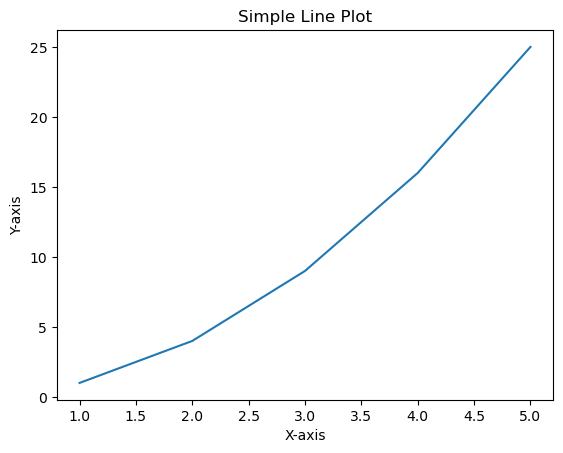

```python
import matplotlib.pyplot as plt
x = [1, 2, 3, 4, 5]
y = [1, 4, 9, 16, 25]
plt.plot(x, y)
plt.title('Simple Line Plot')
plt.xlabel('X-axis')
plt.ylabel('Y-axis')
plt.show()
```

```python
total = df["Salary"].sum()
print(total)
```

```
220000
```

```python
filtered_df=df[df['Age'] <30]
filtered_df
```

|  | name | Age | Salary |
| --- | --- | --- | --- |
| 0 | john | 28 | 40000 |
| 1 | anna | 24 | 50000 |

```python
x=filtered_df['Salary'].sum()/4
x
```

```
22500.0
```

```python
filtered_df=df[df['name']=="john"]
filtered_df
```

|  | name | Age | Salary |
| --- | --- | --- | --- |
| 0 | john | 28 | 40000 |

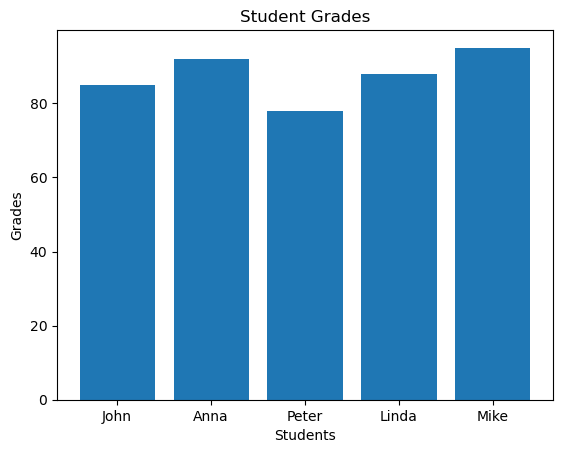

```python
import matplotlib.pyplot as plt
students = ['John', 'Anna', 'Peter', 'Linda', 'Mike']
grades = [85, 92, 78, 88, 95]
plt.bar(students, grades)
plt.title('Student Grades')
plt.xlabel('Students')
plt.ylabel('Grades')
plt.savefig('student_grades.png')
plt.show()
```

```python
pip install numpy
```

```python
import numpy as np
```

```python
arr= np.array([[1,2,3],[4,5,6]])
```

```python
arr2= np.array([[1,2,3],[4,5,6]])
arr2
```

```
array([[1, 2, 3],
       [4, 5, 6]])
```

```python
arr*arr2
```

```
array([[ 1,  4,  9],
       [16, 25, 36]])
```

```python
arr-arr2
```

```
array([[0, 0, 0],
       [0, 0, 0]])
```

```python
max=np.max(arr2)
```

```python
max
```

```
6
```

```python
min1=np.min(arr2)
min1
```

```
1
```

# Day 4

- 1. File Handling:

  • Used open(), read(), and write() for file operations.

• Utilized with for safe file handling.

- 2. Linear Regression:

• Preprocessed data with pandas. • Split data using train_test_split. • Trained and predicted using LinearRegression() from sklearn.

```python
import pandas as pd
from sklearn.linear_model import LinearRegression
from sklearn.model_selection import train_test_split
from sklearn import metrics
data = {'Month': ['Jan', 'Feb', 'Mar', 'Apr', 'May'], 'Spending': [12000, 15000, 18000, 21000, 24000]}
df = pd.DataFrame(data)
df['Month'] = pd.to_datetime(df['Month'], format='%b').dt.month
X = df[['Month']]
y = df['Spending']
X_train, X_test, y_train, y_test = train_test_split(X, y, test_size=0.3, random_state=42)
model = LinearRegression()
model.fit(X_train, y_train)
y_pred = model.predict(X_test)
accuracy = metrics.accuracy_score(y_test, y_pred)
print(f"Accuracy: {accuracy * 100:.2f}%")
prediction = model.predict([[6]])
print(f"Predicted spending for June: {prediction[0]}")
```

```
Accuracy: 100.00%
Predicted spending for June: 27000.0
```